# Study Questions 2 --- BIOL 126

**=======================================================================**

**PLEASE READ THESE INSTRUCTIONS CAREFULLY BEFORE BEGINNING THE STUDY QUESTIONS** **=======================================================================**

These study questions are designed to help you learn and practice the material from Unit 2 (Phylogenetic Diversity, Extinction Rates, Biodiversity–Ecosystem Function, and Values of Biodiversity). The problems here span the **full range of difficulty**, from straightforward introductory questions up through harder problems that are directly comparable to what you will find in the graded homework and quiz.

**We *strongly* suggest that you watch all of the lecture videos and complete the associated readings if you run into a problem that is unfamiliar.** Unit 2 content begins at lecture 2.4 (Phylogenetic Diversity).

Please be sure to work through these study questions, and especially the explanations (using the `?` icon — see below), *before* asking for help with the homework or quiz.

A few notes on the study questions:

- problems are *either* multiple-answer (select all that apply) or have a text entry box for numeric answers
  - many (but not all) of the multiple-answer questions could have more than one correct answer; always read the question carefully and select all answers that apply.
  - if you see a text entry box, that means you should enter a number. **Do not enter any other text besides the numeric value, or it will not be graded as correct.**
- each problem has **icons** below the answer options or answer entry box:
  - at the bottom left of each question is a checkmark `✔️` icon: use this to check your answer once you've entered it
  - the checkmark icon converts to a `↰` icon once you have submitted your answer; you can hit `↰` to clear your response and try again (whether you got it right or wrong)
  - at the bottom right, there is a question mark `?` icon: use this to show an explanation of how to work through the problem. **This is the most important feature of the study questions!** We suggest trying the problem first *without* looking at the explanation, and consulting it only after you've made an attempt. Even if you get a problem right on the first try, it's worth reading the explanation carefully.
  - also at the bottom right is a refresh `↺` icon: clicking this generates a new variant of the problem. The question framing stays the same but the numbers or answer choices change. **You can revisit study questions as many times as you like** — the variety in the pool means each attempt may look a little different. There are 3 different variants of each problem.
  - even if you get a problem right on the first try, we recommend trying at least one or two other variants to build confidence.

In the phylogenetic tree below, which species is/are **most closely related** to species d? Select all that apply.

*(Hint: the most closely related species are the ones that share the most recent common ancestor with species d.)*

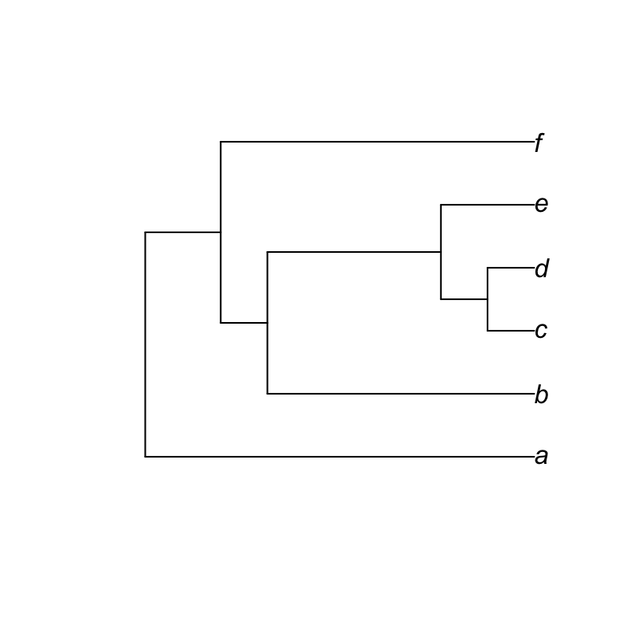

species aspecies bspecies cspecies especies f

The most closely related species to species d is/are species c.

To find the answer, follow the branch leading to species d back (to the left) until it meets the first vertical line — that node is the **most recent common ancestor** of species d and its closest relatives. All of the species descending from that node (other than species d itself) share that ancestor, and are therefore equally closely related to species d.

In the diagram below, species d is shown in orange. The blue lines trace the lineage of its closest relative(s): species c.

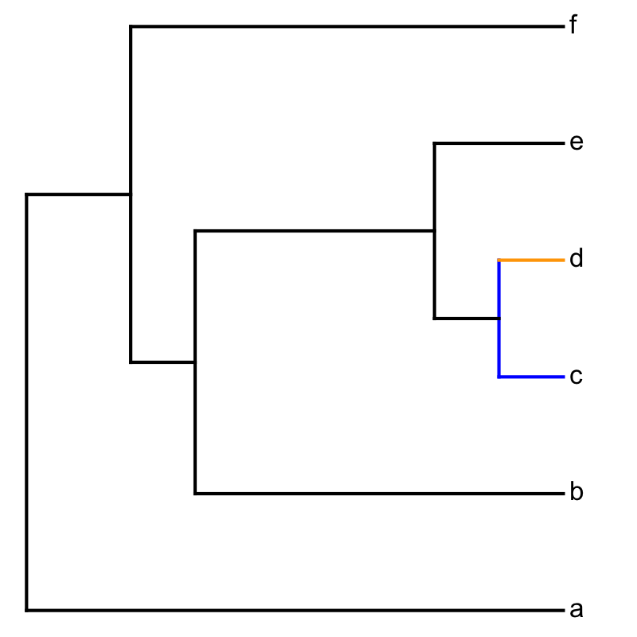

In the phylogenetic tree below, which species is/are **most closely related** to species d? Select all that apply.

*(Hint: the most closely related species are the ones that share the most recent common ancestor with species d.)*

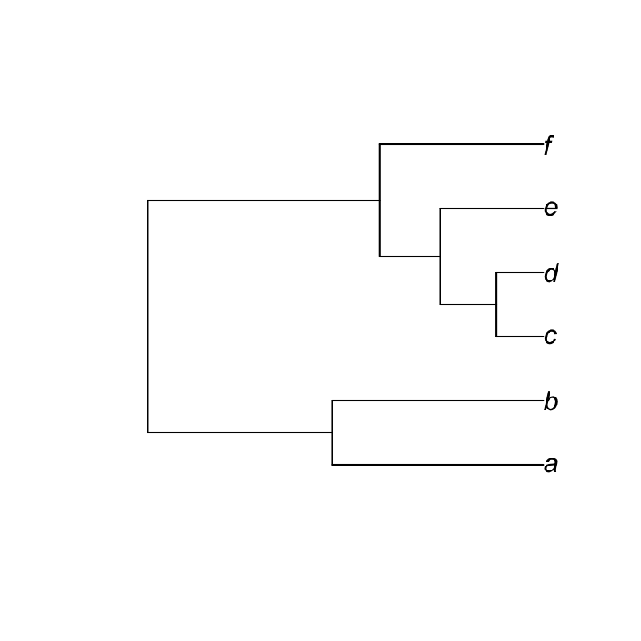

species aspecies bspecies cspecies especies f

The most closely related species to species d is/are species c.

To find the answer, follow the branch leading to species d back (to the left) until it meets the first vertical line — that node is the **most recent common ancestor** of species d and its closest relatives. All of the species descending from that node (other than species d itself) share that ancestor, and are therefore equally closely related to species d.

In the diagram below, species d is shown in orange. The blue lines trace the lineage of its closest relative(s): species c.

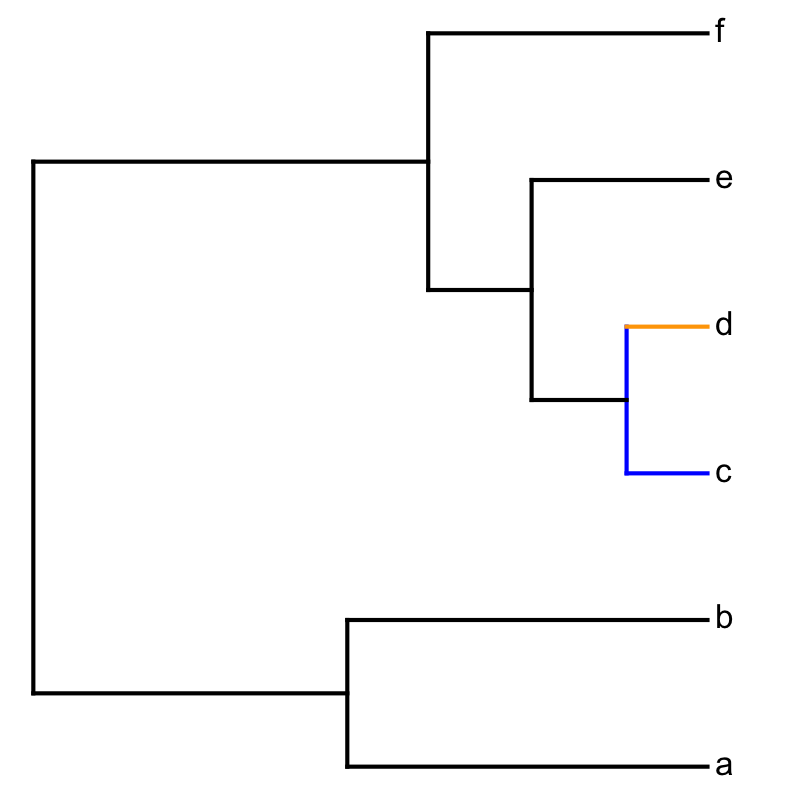

In the phylogenetic tree below, which species is/are **most closely related** to species e? Select all that apply.

*(Hint: the most closely related species are the ones that share the most recent common ancestor with species e.)*

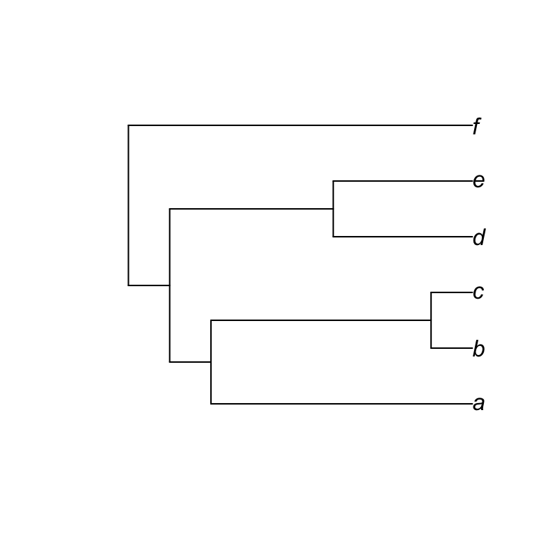

species aspecies bspecies cspecies dspecies f

The most closely related species to species e is/are species d.

To find the answer, follow the branch leading to species e back (to the left) until it meets the first vertical line — that node is the **most recent common ancestor** of species e and its closest relatives. All of the species descending from that node (other than species e itself) share that ancestor, and are therefore equally closely related to species e.

In the diagram below, species e is shown in orange. The blue lines trace the lineage of its closest relative(s): species d.

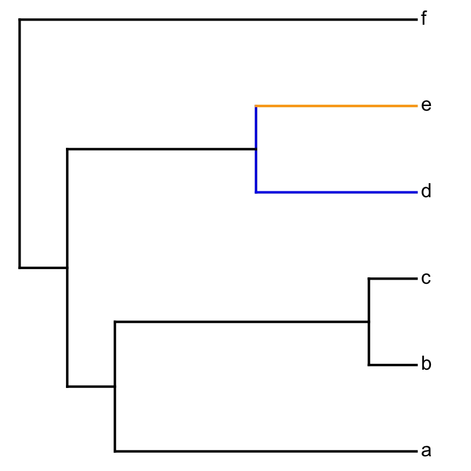

In the phylogenetic tree below, which species is/are **most closely related** to species c? Select all that apply.

*(Hint: the most closely related species are the ones that share the most recent common ancestor with species c.)*

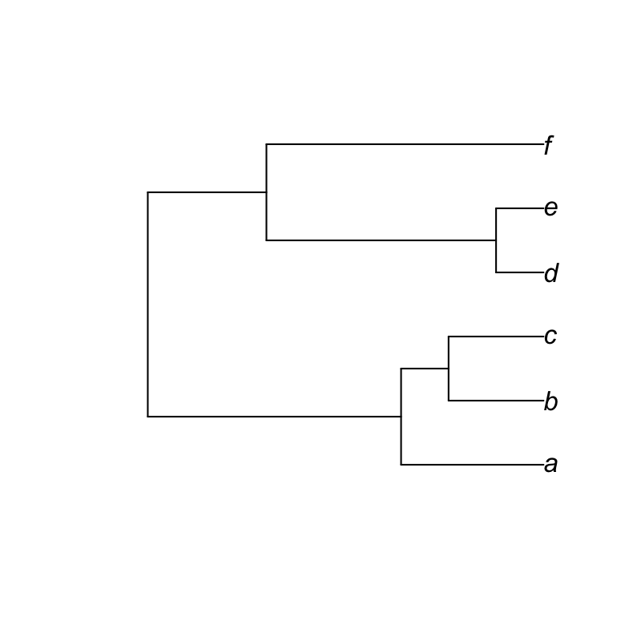

species aspecies bspecies dspecies especies f

The most closely related species to species c is/are species b.

To find the answer, follow the branch leading to species c back (to the left) until it meets the first vertical line — that node is the **most recent common ancestor** of species c and its closest relatives. All of the species descending from that node (other than species c itself) share that ancestor, and are therefore equally closely related to species c.

In the diagram below, species c is shown in orange. The blue lines trace the lineage of its closest relative(s): species b.

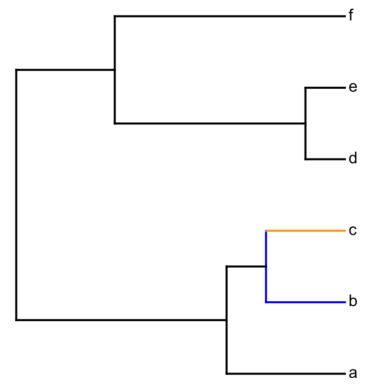

In the phylogenetic tree below, which species is/are **most closely related** to species f? Select all that apply.

*(Hint: the most closely related species are the ones that share the most recent common ancestor with species f.)*

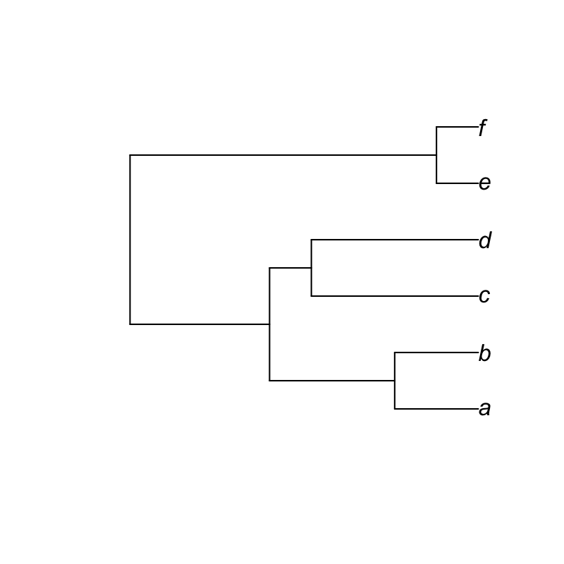

species aspecies bspecies cspecies dspecies e

The most closely related species to species f is/are species e.

To find the answer, follow the branch leading to species f back (to the left) until it meets the first vertical line — that node is the **most recent common ancestor** of species f and its closest relatives. All of the species descending from that node (other than species f itself) share that ancestor, and are therefore equally closely related to species f.

In the diagram below, species f is shown in orange. The blue lines trace the lineage of its closest relative(s): species e.

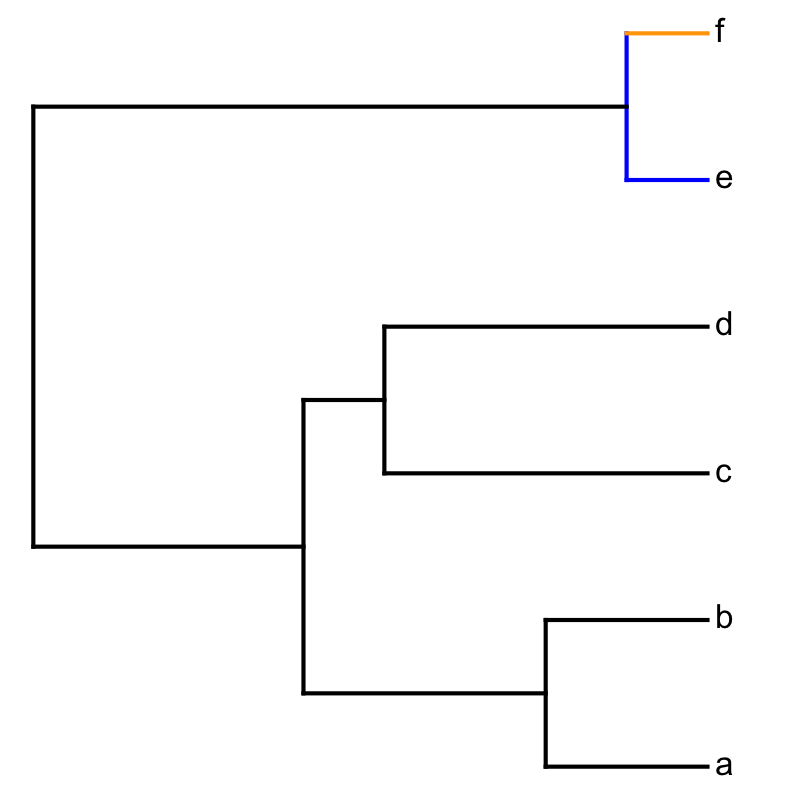

In the phylogenetic tree below, which species is/are **most closely related** to species e? Select all that apply.

*(Hint: the most closely related species are the ones that share the most recent common ancestor with species e.)*

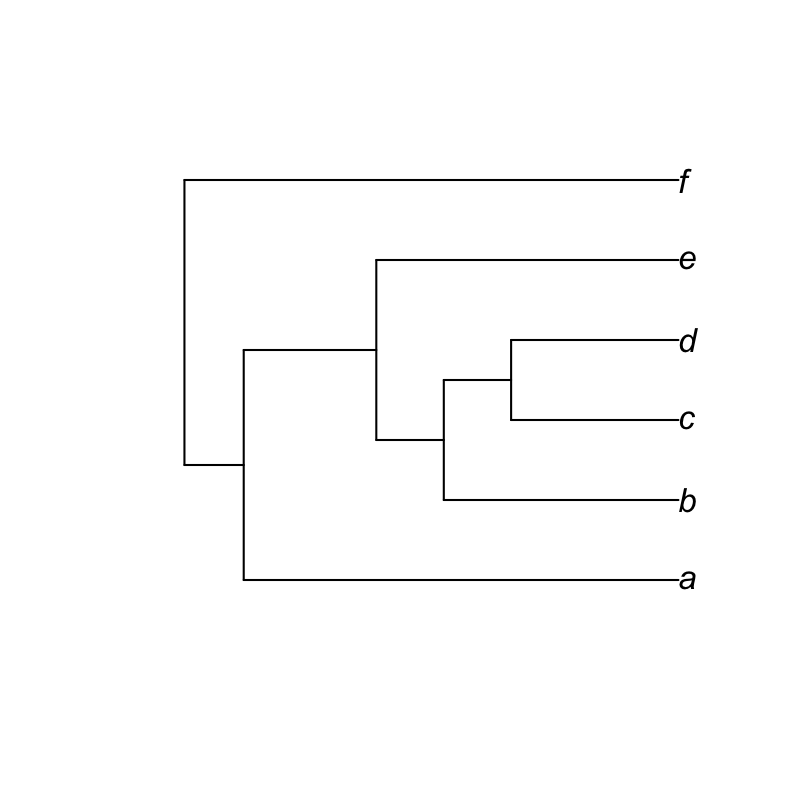

species aspecies bspecies cspecies dspecies f

The most closely related species to species e is/are species b, species c, species d.

To find the answer, follow the branch leading to species e back (to the left) until it meets the first vertical line — that node is the **most recent common ancestor** of species e and its closest relatives. All of the species descending from that node (other than species e itself) share that ancestor, and are therefore equally closely related to species e.

In the diagram below, species e is shown in orange. The blue lines trace the lineage of its closest relative(s): species b, species c, species d.

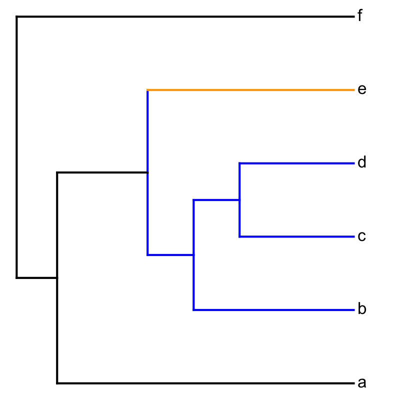

**Which species are the closest relatives of species d?** Select all that apply. There may be one closest relative or several.

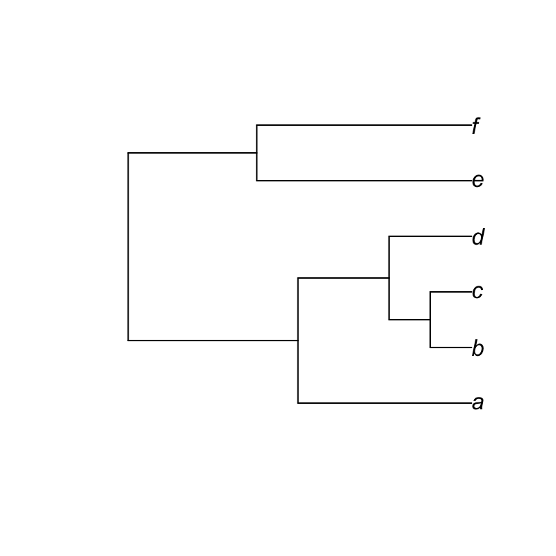

species aspecies bspecies cspecies especies f

The closest relative(s) of species d is/are species b, species c.

Starting from species d, trace the branch back (left) to the first internal node — the most recent common ancestor. All branches leading from that node to species other than species d are equally closely related. In the tree below, species d is drawn in orange, and its closest relative(s) are traced in blue.

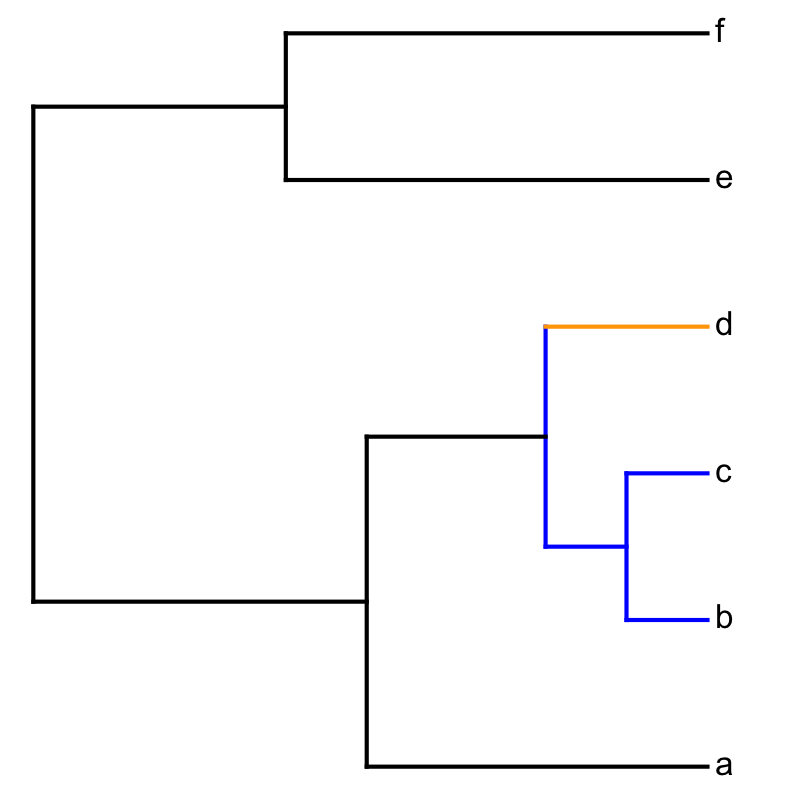

**Which species are the closest relatives of species a?** Select all that apply. There may be one closest relative or several.

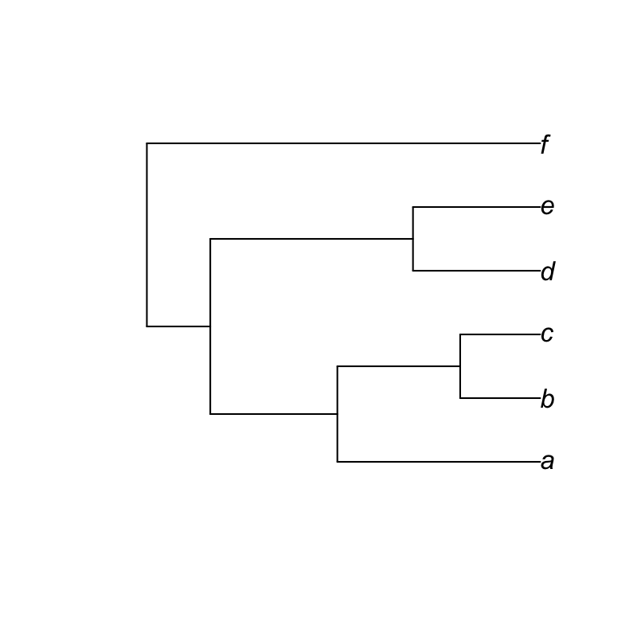

species bspecies cspecies dspecies especies f

The closest relative(s) of species a is/are species b, species c.

Starting from species a, trace the branch back (left) to the first internal node — the most recent common ancestor. All branches leading from that node to species other than species a are equally closely related. In the tree below, species a is drawn in orange, and its closest relative(s) are traced in blue.

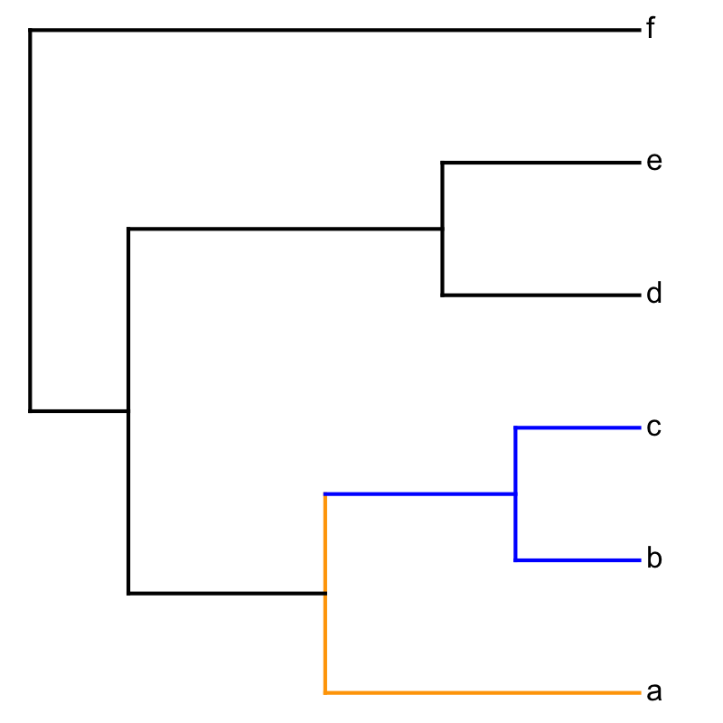

**Which species are the closest relatives of species a?** Select all that apply. There may be one closest relative or several.

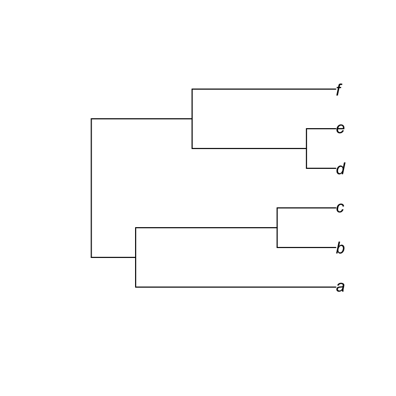

species bspecies cspecies dspecies especies f

The closest relative(s) of species a is/are species b, species c.

Starting from species a, trace the branch back (left) to the first internal node — the most recent common ancestor. All branches leading from that node to species other than species a are equally closely related. In the tree below, species a is drawn in orange, and its closest relative(s) are traced in blue.

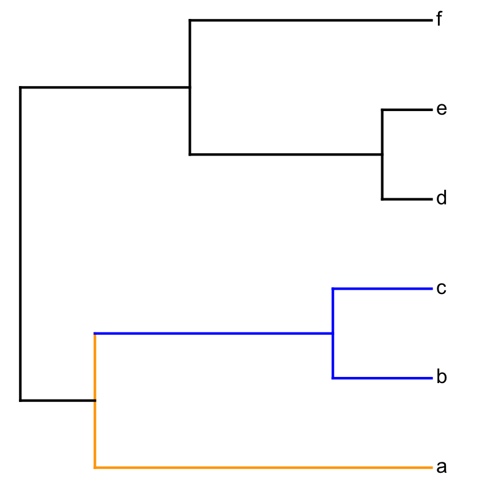

**Which species are the closest relatives of species c?** Select all that apply. There may be one closest relative or several.

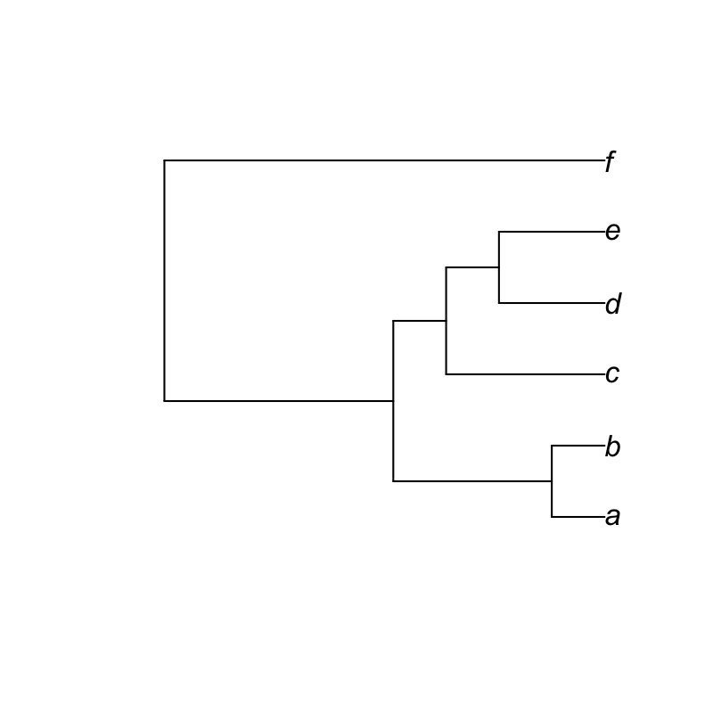

species aspecies bspecies dspecies especies f

The closest relative(s) of species c is/are species d, species e.

Starting from species c, trace the branch back (left) to the first internal node — the most recent common ancestor. All branches leading from that node to species other than species c are equally closely related. In the tree below, species c is drawn in orange, and its closest relative(s) are traced in blue.

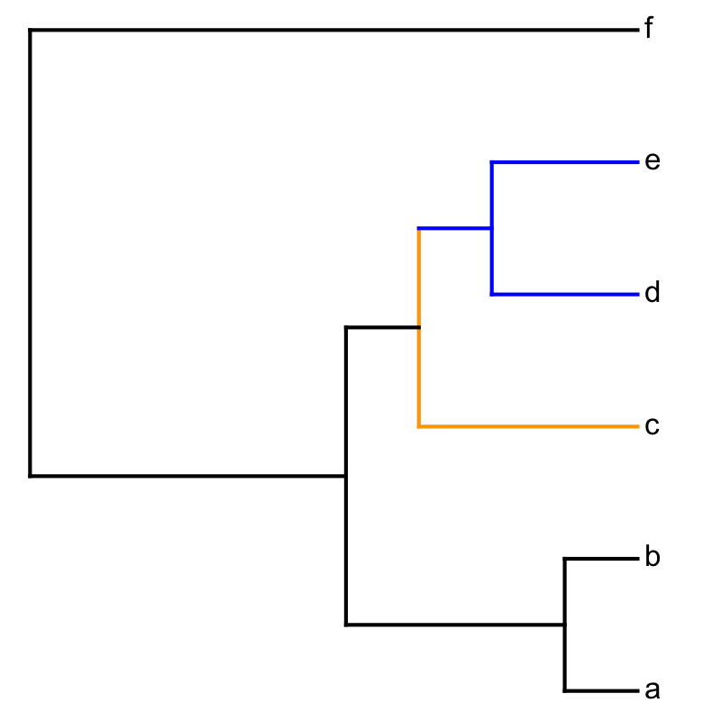

**Which species are the closest relatives of species c?** Select all that apply. There may be one closest relative or several.

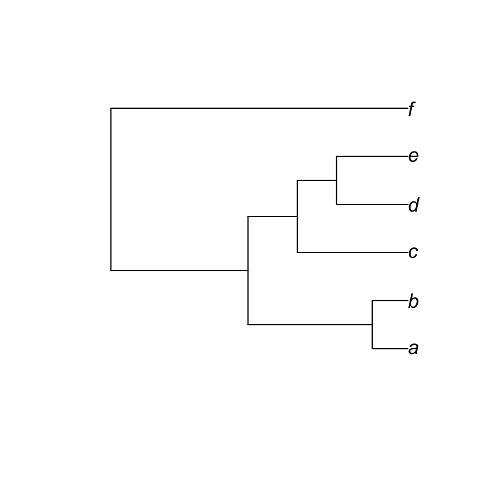

species aspecies bspecies dspecies especies f

The closest relative(s) of species c is/are species d, species e.

Starting from species c, trace the branch back (left) to the first internal node — the most recent common ancestor. All branches leading from that node to species other than species c are equally closely related. In the tree below, species c is drawn in orange, and its closest relative(s) are traced in blue.

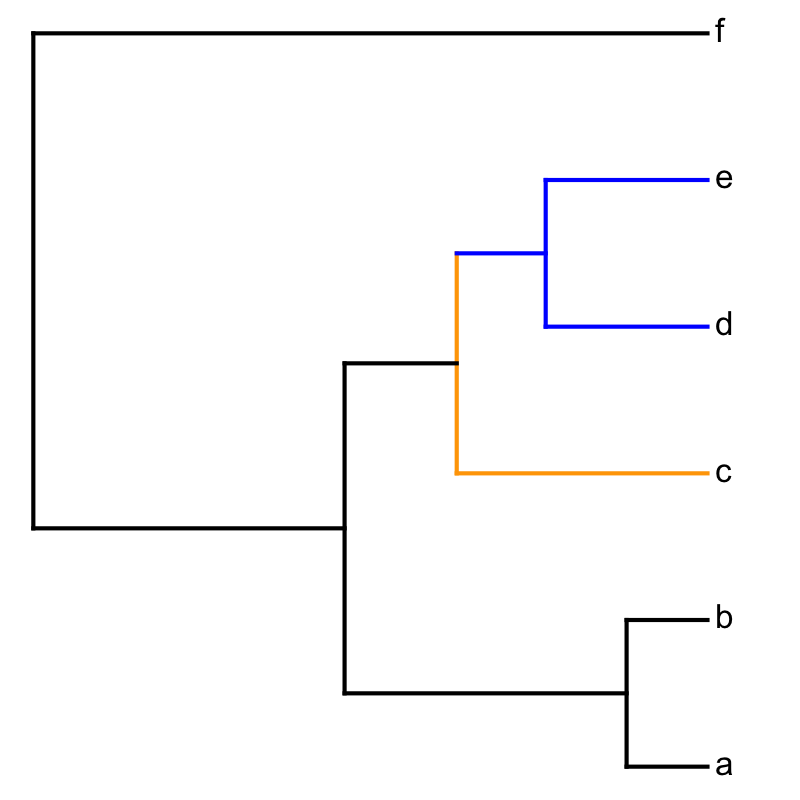

**Which species are the closest relatives of species f?** Select all that apply. There may be one closest relative or several.

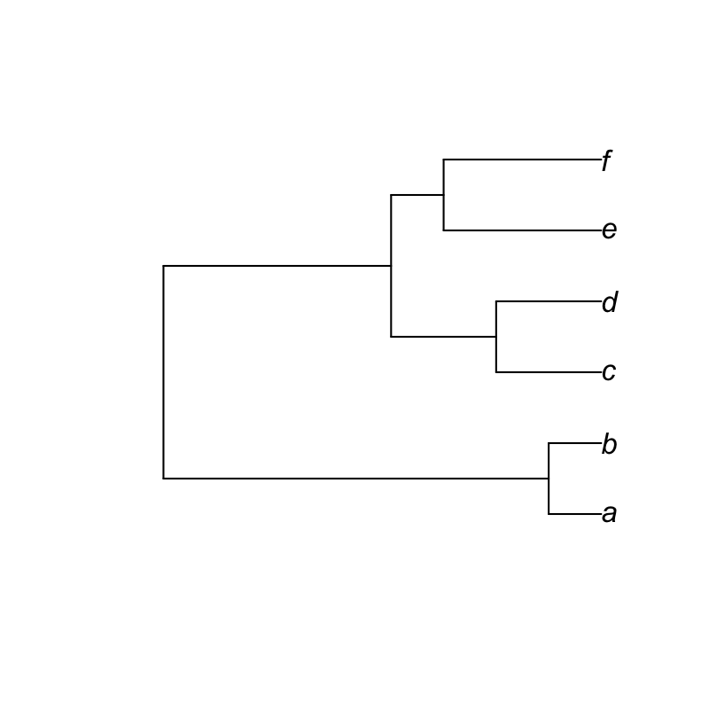

species aspecies bspecies cspecies dspecies e

The closest relative(s) of species f is/are species e.

Starting from species f, trace the branch back (left) to the first internal node — the most recent common ancestor. All branches leading from that node to species other than species f are equally closely related. In the tree below, species f is drawn in orange, and its closest relative(s) are traced in blue.

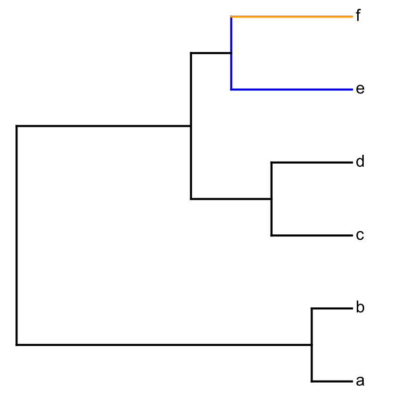

**Which species form the *largest group of equally related* species to species a?** Select all members of that group.

Note: there may be several *different* groups of equally related species to species a (at different distances), but you are looking for the **largest** of those groups.

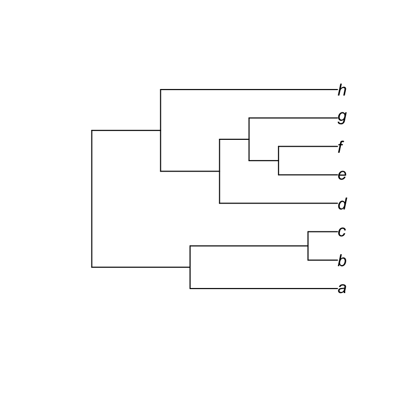

species bspecies cspecies dspecies especies fspecies gspecies h

The largest group of equally related species to species a is: species d, species e, species f, species g, species h.

To solve this, follow the branch of species a back toward the root. At each internal node (vertical line), count how many species descend from the other side. Each such group is *equally related* to species a at that distance. You want the **largest** of these groups.

In the diagram below, species a is shown in orange, and the largest equally related group (species d, species e, species f, species g, species h) is shown in blue.

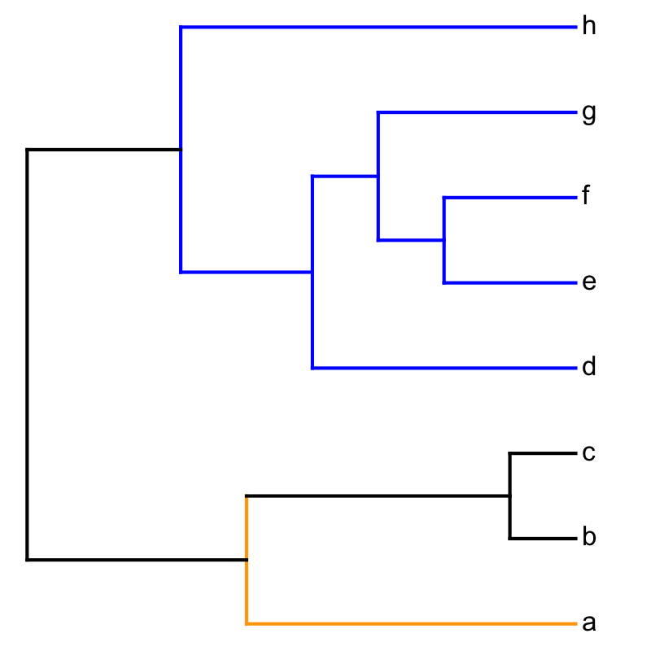

**Which species form the *largest group of equally related* species to species d?** Select all members of that group.

Note: there may be several *different* groups of equally related species to species d (at different distances), but you are looking for the **largest** of those groups.

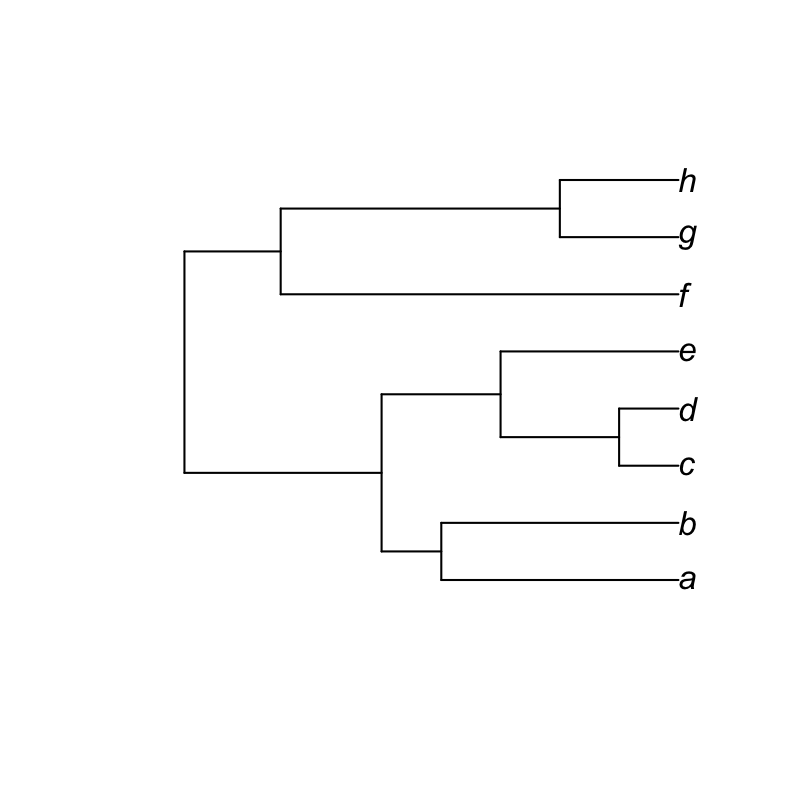

species aspecies bspecies cspecies especies fspecies gspecies h

The largest group of equally related species to species d is: species f, species g, species h.

To solve this, follow the branch of species d back toward the root. At each internal node (vertical line), count how many species descend from the other side. Each such group is *equally related* to species d at that distance. You want the **largest** of these groups.

In the diagram below, species d is shown in orange, and the largest equally related group (species f, species g, species h) is shown in blue.

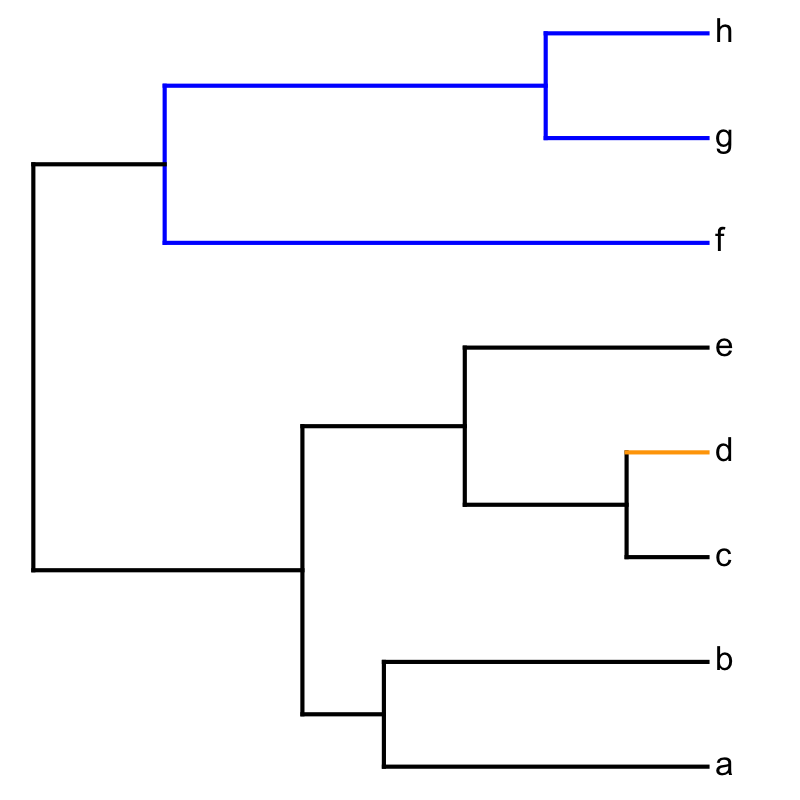

**Which species form the *largest group of equally related* species to species e?** Select all members of that group.

Note: there may be several *different* groups of equally related species to species e (at different distances), but you are looking for the **largest** of those groups.

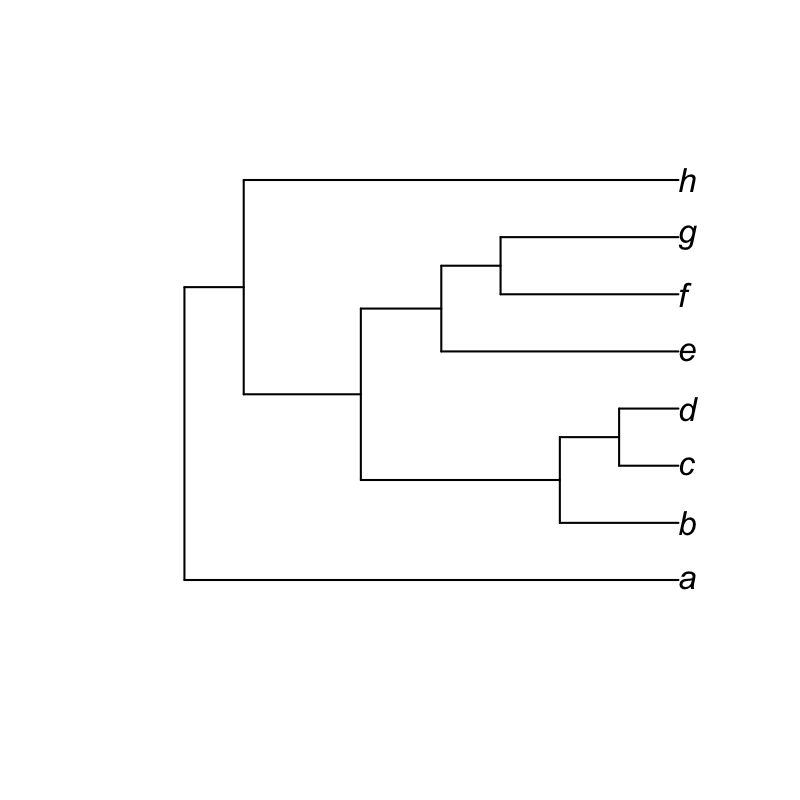

species aspecies bspecies cspecies dspecies fspecies gspecies h

The largest group of equally related species to species e is: species b, species c, species d.

To solve this, follow the branch of species e back toward the root. At each internal node (vertical line), count how many species descend from the other side. Each such group is *equally related* to species e at that distance. You want the **largest** of these groups.

In the diagram below, species e is shown in orange, and the largest equally related group (species b, species c, species d) is shown in blue.

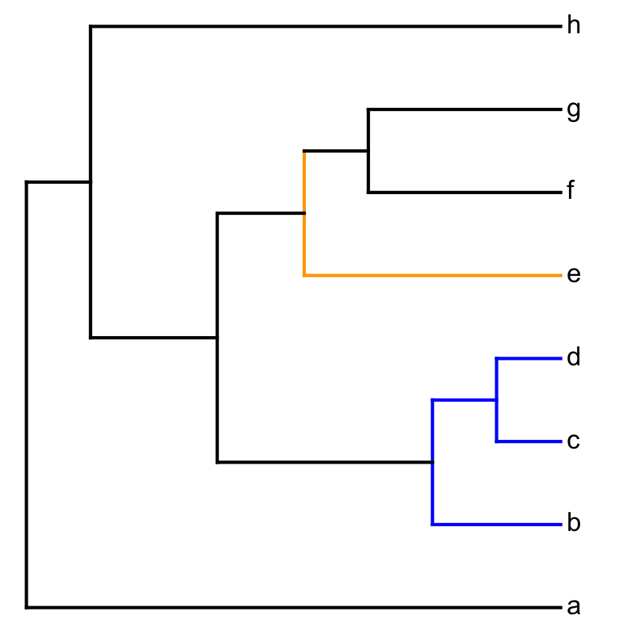

**Which species form the *largest group of equally related* species to species c?** Select all members of that group.

Note: there may be several *different* groups of equally related species to species c (at different distances), but you are looking for the **largest** of those groups.

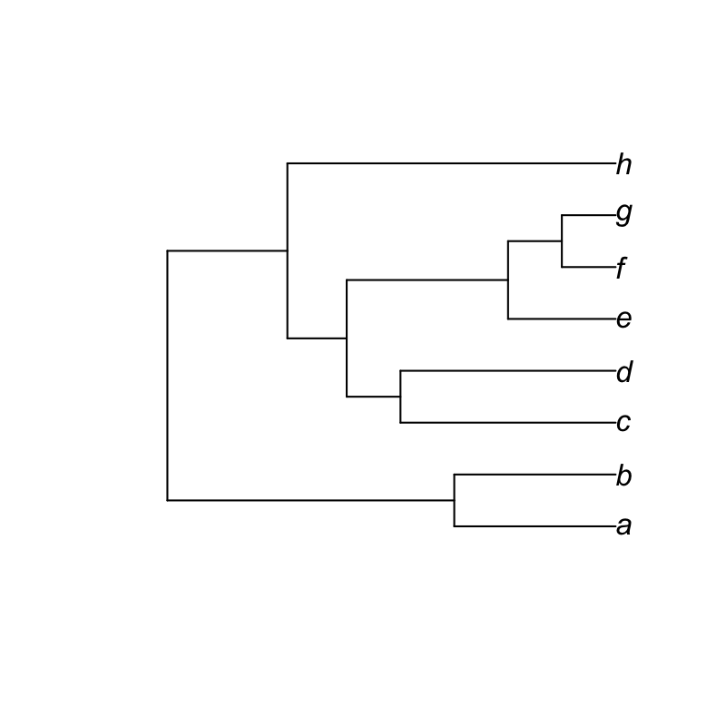

species aspecies bspecies dspecies especies fspecies gspecies h